# BD N de Sant. GLM

Acevedo, et.al.,

23 de enero de 2018

## Read packages

```r
knitr::opts_chunk$set(echo = TRUE)

library(sp)
library(rgdal)
library(raster)
library(rgdal)
library(dismo)
library(rasterVis)
library(xtable)
```

### Read Data

```r
# Path to working directory
path <- "C:/Users/diego.lizcano/Documents/GitHub/Bd_N_Santander/data"

BD1<-readOGR(dsn=path, layer="BD")
```

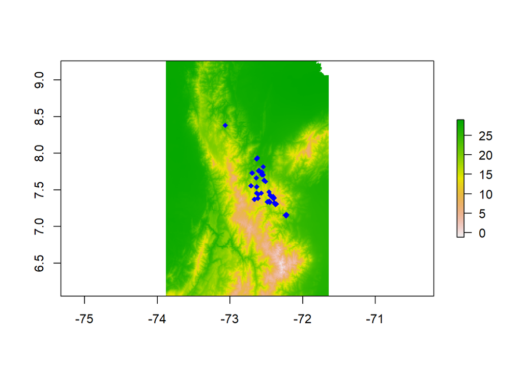

```r
###cargando variables ambientales
files <- list.files(path=path, pattern='tif', full.names=TRUE )

# View(files)
# Agrupar las variables ambientales en un objeto stack
predictors <- stack(files)
# names(predictors)
plot(predictors$Bio1)
plot(BD1, pch=18, add=TRUE, col="blue", main="Batrachochytrium dendrobatidis")
```

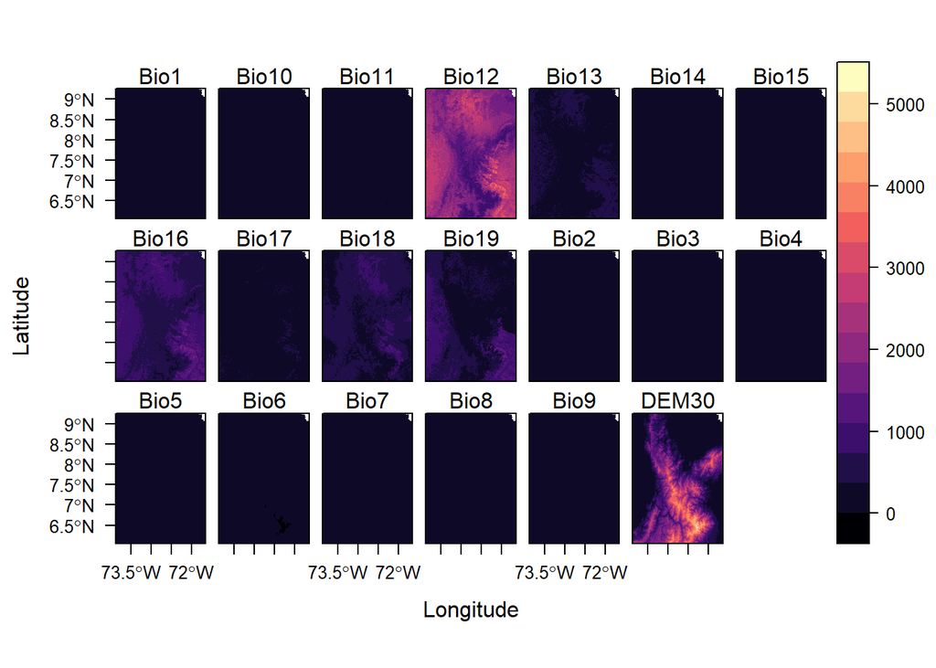

```r
levelplot(predictors)
```

```r
#Extraer la informacion de variables ambientales por ptos. con presencia de BD

# head(BD)
BD <- BD1[,-1] # quito la primera columna
head(BD)
```

```
##           X        Y Diagnostic
## 1 -73.06614 8.380760          1
## 2 -72.62444 7.936156          1
## 3 -72.63474 7.920514          1
## 4 -72.63305 7.542250          1
## 5 -72.54150 7.815944          1
## 6 -72.57844 7.727333          1
```

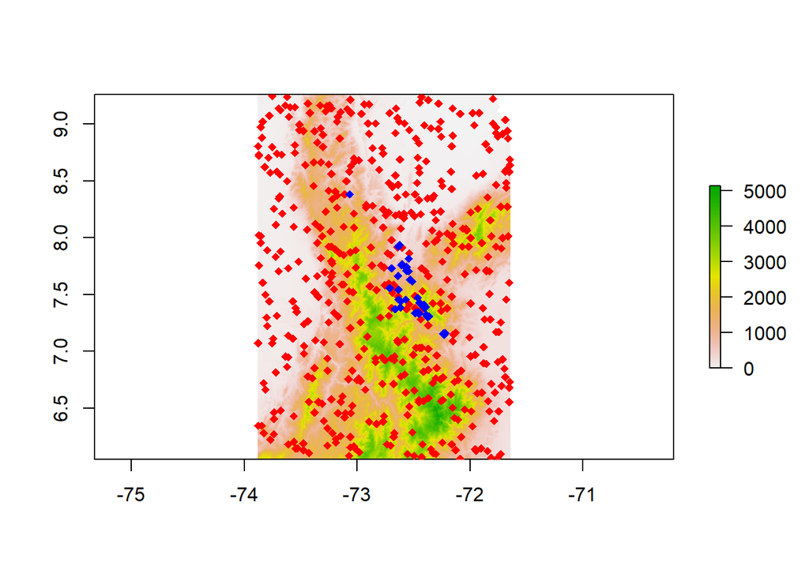

```r
names(BD)[1]<-paste("x")
names(BD)[2]<-paste("y") # re nombro encabezados de  columnas
# head(BD)

presvals <- (BD)

###presvals <- extract(predictors, BD)

set.seed(2000)
backg <- randomPoints(predictors, n=500, extf = 1.25)


plot(predictors$DEM30)
points(backg, pch=18, col="red")
plot(BD1, pch=18, add=TRUE, col="blue", main="Batrachochytrium dendrobatidis")
```

```r
#generando datos de prueba y entrenamiento con los datos de presencia y pseudo-ausencia con particion 80-20%
indexes_pres = sample(1:nrow(presvals), size=0.2*nrow(presvals))
indexes_backg = sample(1:nrow(backg), size=0.2*nrow(backg))

###Presencias
#identifica el 20% de los datos como datos prueba/test
pres_test = presvals[indexes_pres,]
dim(pres_test)
```

```
## [1] 10  3
```

```r
#identifica el 80% de los datos como datos entrenamiento/train
pres_train = presvals[-indexes_pres,]
dim(pres_train)
```

```
## [1] 44  3
```

```r
# View(pres_train)


###pseudo-ausencia
#identifica el 20% de los datos como datos prueba/test
backg_test = backg[indexes_backg,]
dim(backg_test)
```

```
## [1] 100   2
```

```r
#identifica el 80% de los datos como datos entrenamiento/train
backg_train = backg[-indexes_backg,]
dim(backg_train)
```

```
## [1] 400   2
```

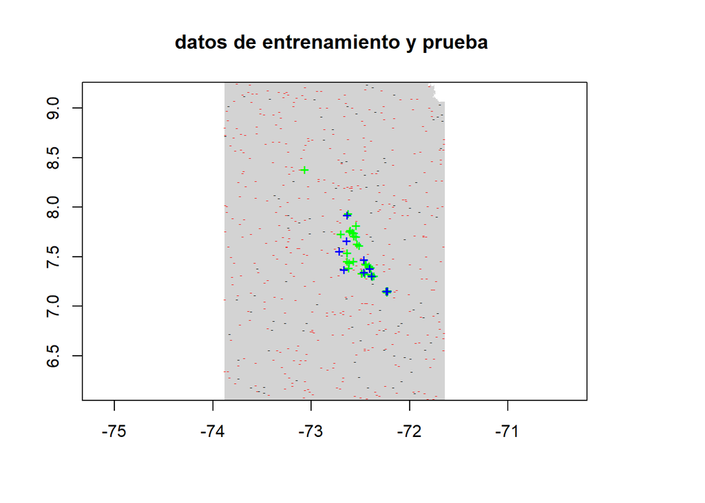

```r
# mapeando los datos de entrenamiento y prueba de presencias y backg
r = raster(predictors, 1)
plot(!is.na(r), col=c('white', 'light grey'), legend=FALSE, main="datos de entrenamiento y prueba ")
points(backg_train, pch='-', cex=0.5, col='red')
points(backg_test, pch='-', cex=0.5, col='black')
points(pres_train, pch= '+', col='green')
points(pres_test, pch='+', col='blue')
```

```r
trainpres <- data.frame( extract(predictors, pres_train) )
trainbackg <- data.frame( extract(predictors, backg_train) )
train <- rbind(trainpres, trainbackg)
pb_train <- c(rep(1, nrow(trainpres)), rep(0, nrow(trainbackg)))
envtrain <- data.frame( cbind(pa=pb_train, train) )


#### extract from stack
testpres <- data.frame( extract(predictors, pres_test) )
testbackg <- data.frame( extract(predictors, backg_test) )

# head(envtrain)


#Ajuste del modelo GLM y predicc??n
# GLM binomial
gm1 <- glm(pa ~ Bio1 + Bio2 + Bio3 + Bio4 + Bio5 + Bio6 + Bio7 + Bio8 + Bio9 + Bio10 + Bio11 + Bio12 + Bio13 + Bio14 + Bio15 + Bio16 + Bio17 + Bio18 + Bio19 + DEM30,family = binomial(link = "logit"), data=envtrain)
summary(gm1)
```

```
##
## Call:
## glm(formula = pa ~ Bio1 + Bio2 + Bio3 + Bio4 + Bio5 + Bio6 +
##     Bio7 + Bio8 + Bio9 + Bio10 + Bio11 + Bio12 + Bio13 + Bio14 +
##     Bio15 + Bio16 + Bio17 + Bio18 + Bio19 + DEM30, family = binomial(link = "logit"),
##     data = envtrain)
##
## Deviance Residuals:
##     Min       1Q   Median       3Q      Max
## -1.8262  -0.3164  -0.1262  -0.0170   3.3506
##
## Coefficients:
##               Estimate Std. Error z value Pr(>|z|)
## (Intercept)  1.064e+02  6.167e+01   1.725  0.08455 .
## Bio1         1.782e+01  6.596e+00   2.702  0.00689 **
## Bio2         8.517e+00  7.276e+00   1.171  0.24177
## Bio3        -9.305e-01  7.025e-01  -1.325  0.18531
## Bio4        -1.636e-01  1.670e-01  -0.980  0.32727
## Bio5         4.118e+05  2.125e+06   0.194  0.84635
## Bio6        -4.118e+05  2.125e+06  -0.194  0.84635
## Bio7        -4.118e+05  2.125e+06  -0.194  0.84635
## Bio8         4.979e+00  1.891e+00   2.633  0.00847 **
## Bio9        -7.806e+00  1.730e+00  -4.512 6.41e-06 ***
## Bio10       -1.073e+01  6.323e+00  -1.697  0.08966 .
## Bio11       -2.781e+00  6.782e+00  -0.410  0.68176
## Bio12       -1.019e-03  2.510e-03  -0.406  0.68481
## Bio13       -7.774e-03  1.105e-02  -0.704  0.48157
## Bio14       -4.569e-02  2.321e-02  -1.968  0.04903 *
## Bio15       -1.542e-02  7.796e-02  -0.198  0.84322
## Bio16        1.251e-03  6.157e-03   0.203  0.83901
## Bio17        8.391e-03  1.021e-02   0.822  0.41110
## Bio18       -2.301e-03  2.867e-03  -0.802  0.42228
## Bio19        5.943e-03  2.050e-03   2.899  0.00374 **
## DEM30       -4.150e-03  1.390e-03  -2.985  0.00283 **
## ---
## Signif. codes:  0 '***' 0.001 '**' 0.01 '*' 0.05 '.' 0.1 ' ' 1
##
## (Dispersion parameter for binomial family taken to be 1)
##
##     Null deviance: 286.91  on 443  degrees of freedom
## Residual deviance: 173.29  on 423  degrees of freedom
## AIC: 215.29
##
## Number of Fisher Scoring iterations: 8
```

```r
coef(gm1)
```

```
##   (Intercept)          Bio1          Bio2          Bio3          Bio4
##  1.063801e+02  1.782204e+01  8.516710e+00 -9.304713e-01 -1.636418e-01
##          Bio5          Bio6          Bio7          Bio8          Bio9
##  4.117560e+05 -4.117581e+05 -4.117646e+05  4.978916e+00 -7.806320e+00
##         Bio10         Bio11         Bio12         Bio13         Bio14
## -1.073107e+01 -2.781057e+00 -1.018781e-03 -7.773728e-03 -4.568756e-02
##         Bio15         Bio16         Bio17         Bio18         Bio19
## -1.541791e-02  1.250792e-03  8.391070e-03 -2.300673e-03  5.943058e-03
##         DEM30
## -4.150483e-03
```

```r
# GLM gausiano
gm2 <- glm(pa ~ Bio1 + Bio2 + Bio3 + Bio4 + Bio5 + Bio6 + Bio7 + Bio8 + Bio9 + Bio10 + Bio11 + Bio12 + Bio13 + Bio14 + Bio15 + Bio16 + Bio17 + Bio18 + Bio19 + DEM30,family = gaussian(link = "identity"), data=envtrain)
summary(gm2)
```

```
##
## Call:
## glm(formula = pa ~ Bio1 + Bio2 + Bio3 + Bio4 + Bio5 + Bio6 +
##     Bio7 + Bio8 + Bio9 + Bio10 + Bio11 + Bio12 + Bio13 + Bio14 +
##     Bio15 + Bio16 + Bio17 + Bio18 + Bio19 + DEM30, family = gaussian(link = "identity"),
##     data = envtrain)
##
## Deviance Residuals:
##      Min        1Q    Median        3Q       Max
## -0.41261  -0.14746  -0.06648   0.02656   0.94159
##
## Coefficients:
##               Estimate Std. Error t value Pr(>|t|)
## (Intercept)  9.241e-01  2.908e+00   0.318 0.750775
## Bio1         4.390e-01  2.971e-01   1.478 0.140282
## Bio2        -1.365e-01  3.345e-01  -0.408 0.683459
## Bio3         1.677e-02  3.356e-02   0.500 0.617505
## Bio4         3.833e-03  6.328e-03   0.606 0.545017
## Bio5         8.142e+04  1.555e+05   0.523 0.600910
## Bio6        -8.142e+04  1.555e+05  -0.523 0.600910
## Bio7        -8.142e+04  1.555e+05  -0.523 0.600910
## Bio8         1.920e-01  8.794e-02   2.183 0.029606 *
## Bio9        -2.058e-01  7.771e-02  -2.649 0.008378 **
## Bio10       -5.171e-01  2.810e-01  -1.840 0.066464 .
## Bio11        1.942e-02  2.746e-01   0.071 0.943663
## Bio12        6.289e-05  1.513e-04   0.416 0.677868
## Bio13       -1.569e-04  5.906e-04  -0.266 0.790655
## Bio14       -2.502e-03  1.494e-03  -1.675 0.094654 .
## Bio15       -1.606e-03  4.799e-03  -0.335 0.738074
## Bio16       -1.167e-04  3.445e-04  -0.339 0.735040
## Bio17        4.443e-05  5.975e-04   0.074 0.940757
## Bio18       -1.478e-04  1.683e-04  -0.878 0.380572
## Bio19        3.181e-04  1.001e-04   3.178 0.001592 **
## DEM30       -3.334e-04  9.517e-05  -3.503 0.000508 ***
## ---
## Signif. codes:  0 '***' 0.001 '**' 0.01 '*' 0.05 '.' 0.1 ' ' 1
##
## (Dispersion parameter for gaussian family taken to be 0.0774165)
##
##     Null deviance: 39.640  on 443  degrees of freedom
## Residual deviance: 32.747  on 423  degrees of freedom
## AIC: 146.51
##
## Number of Fisher Scoring iterations: 2
```

```r
coef(gm2)
```

```
##   (Intercept)          Bio1          Bio2          Bio3          Bio4
##  9.241218e-01  4.390238e-01 -1.365051e-01  1.677058e-02  3.833013e-03
##          Bio5          Bio6          Bio7          Bio8          Bio9
##  8.141698e+04 -8.141697e+04 -8.141690e+04  1.919517e-01 -2.058373e-01
##         Bio10         Bio11         Bio12         Bio13         Bio14
## -5.170827e-01  1.941800e-02  6.289456e-05 -1.568926e-04 -2.501821e-03
##         Bio15         Bio16         Bio17         Bio18         Bio19
## -1.605737e-03 -1.166529e-04  4.443371e-05 -1.477622e-04  3.180856e-04
##         DEM30
## -3.334307e-04
```

```r
## evaluacion
ge1 <- evaluate(testpres, testbackg, gm1)
ge1
```

```
## class          : ModelEvaluation
## n presences    : 10
## n absences     : 100
## AUC            : 0.867
## cor            : 0.2735291
## max TPR+TNR at : -1.809294
```

```r
ge2 <- evaluate(testpres, testbackg, gm2)
ge2
```

```
## class          : ModelEvaluation
## n presences    : 10
## n absences     : 100
## AUC            : 0.822
## cor            : 0.3157062
## max TPR+TNR at : 0.2317657
```

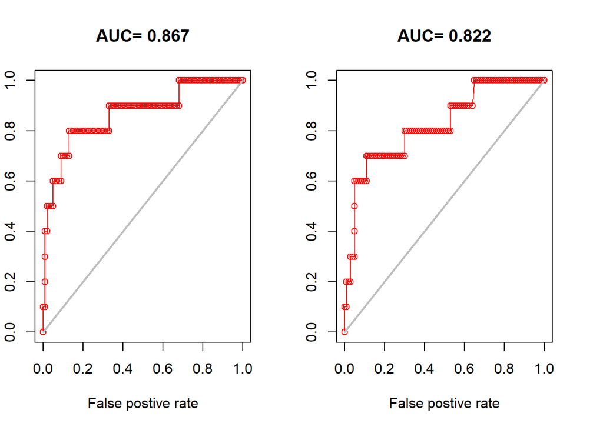

```r
par(mfrow=c(1,2))
plot(ge1, 'ROC', main="ge1")
plot(ge2, 'ROC', main="ge2")
```

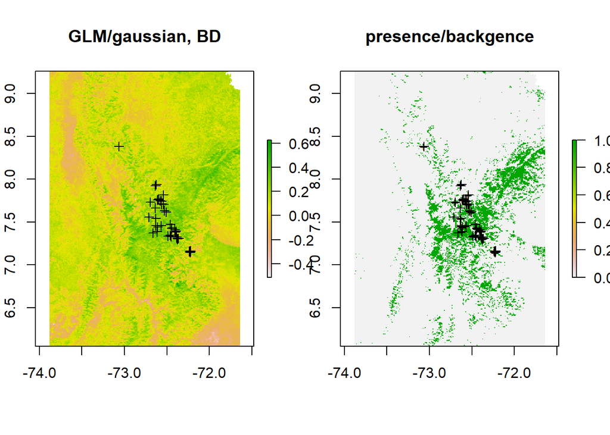

```r
##mapeo del modelo
pg <- predict(predictors, gm2, ext=predictors)
par(mfrow=c(1,2))
plot(pg, main='GLM/gaussian, BD')
plot(BD, add=TRUE, border='dark grey')
tr <- threshold(ge2, 'spec_sens')
plot(pg>tr, main='presence/backgence')
plot(BD, add=TRUE, border='dark grey')
points(pres_train, pch='+')
```

```r
dev.off()
```

# Comentarios

1. En terminos generales el codigo esta bien mis comentarios son mas a los datos y la seleccion del modelo que predice.
2. Creo que es mejor si usa los datos de presencia ausencia reales en lugar de pseudo ausencias al azar. Si tiene y puede recuperar los datos de las coordenadas de los bichos con deteccion negativa es es mucho mejor.
3. En mi opinion es mejor que haga una preseleccion de variables para trabajar con las que no estan correlacionadas. En teoria la altitud y la temperatura lo estan, asi que indicarian lo mismo y al predecir esto introduce ruido de sobreprediccion.
4. Es raro que haga un modelo gausiano (normal) con datos de presencia ausencia. Es mejor uno binomial. En el binomial vale la pena probar con combinaciones cuadraticas y exponenciales de alguna variables ya que no siempre la relacion es lineal.
5. Si el ciriterio de seleccion del mejor modelo es el AUC hay que seleccionar el mayor AUC para predecir.
6. En mi opinion la ventana de prediccion es demasiado grande comparado con la extension de los puntos de presencia.